# Steel Supplier Analysis

# Регрессионный анализ

Загружаем данные в объект Data.Frame и добавляем количество несломанных мечей для каждой партии, а также процент сломавшихся в последний месяц мечей к количеству несломанных.

```r
steel <- read.csv("production-data.csv")
steel <- steel %>%
  group_by(unsullen.id, production.date) %>%
  mutate(
    unbroken = lag(cumsum(produced) - cumsum(defects)),
    broke_perc = defects / unbroken
  )
```

Найдем средние значения процента сломавшихся мечей по кузнецам.

```r
steel.sum <- steel %>%
  group_by(supplier, production.date, report.date) %>%
  filter(production.date != report.date) %>%
  summarize(
    mean = mean(broke_perc)
  )
```

Найдем среднее геометрическое значения процента сломавшихся мечей по времени использования меча, а также для каждой партии найдем отклонение от этого среднего.

```r
steel.sum <- steel.sum %>%
  group_by(supplier, report.date - production.date) %>%
  mutate(
    memean = exp(mean(log(mean))),
    deviation = mean/memean
  )
```

Выведем наглядную зависимость процента сломавшихся мечей от месяца репорта и месяца производства.

```r
steel.time <- steel.sum %>%
  ungroup() %>%
  select(supplier, report.date, production.date, deviation) %>%
  spread(report.date, deviation)
option(knitr.kable.NA = '')
kable(steel.time, format="markdown"
```

|  | supplier | production.date | 2 | 3 | 4 | 5 | 6 | 7 |
| --- | --- | --- | --- | --- | --- | --- | --- | --- |
| 1 | harpy.co | 1 | 0.9696078 | 1.0046407 | 1.019789 | 1.0221937 | 1.0075033 | 1.0000000 |
| 2 | harpy.co | 2 | NA | 1.0200700 | 1.032068 | 1.0619275 | 0.9837887 | 0.9925526 |
| 3 | harpy.co | 3 | NA | NA | 1.009517 | 1.0084505 | 0.8642836 | 0.9944089 |
| 4 | harpy.co | 4 | NA | NA | NA | 1.0028517 | 1.0224166 | 1.0684119 |
| 5 | harpy.co | 5 | NA | NA | NA | NA | 1.0235991 | 0.9354019 |
| 6 | harpy.co | 6 | NA | NA | NA | NA | NA | 0.9756488 |
| 7 | westeros.inc | 1 | 1.0019465 | 0.9831676 | 1.070277 | 0.9394950 | 0.9451071 | 1.0000000 |
| 8 | westeros.inc | 2 | NA | 0.9967793 | 1.031749 | 0.9554881 | 1.0135308 | 1.0580812 |
| 9 | westeros.inc | 3 | NA | NA | 1.028123 | 1.0407349 | 1.0498993 | 1.0501916 |
| 10 | westeros.inc | 4 | NA | NA | NA | 1.0056238 | 0.9909514 | 0.9313887 |

[output cut: 2 more lines]

Все значения близки к единице. Получили, что процент сломавшихся мечей не зависит от месяца ведения войны и не зависит от месяца поступления стали. В такой случае достаточно наблюдать зависимость процента сломанных мечей от времени их использования отдельно по каждому производителю.

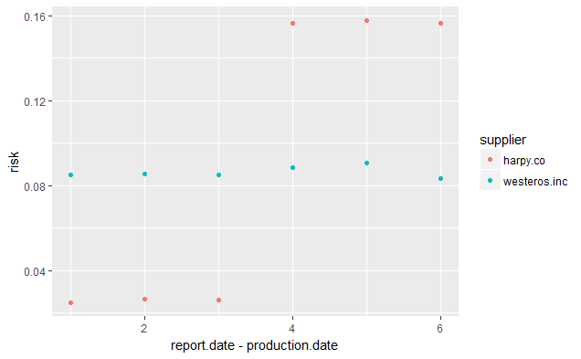

```r
steel.sword.life <- steel %>%
  group_by(supplier, report.date - production.date) %>%
  filter(report.date - production.date != 0) %>%
  summarize(
    defects.sum = sum(defects),
    swords.sum = sum(unbroken),
    risk = defects.sum/swords.sum
  )
ggplot(steel.sword.life, aes(x = `report.date - production.date`, y = risk)) +
         geom_point(aes(colour = supplier))
```

По полученному графику можно сделать предположение о том, что в Westeros.Inc вероятность поломки меча постоянная во времени, а в Harpy.Co первые три месяца низкая, а потом резко возрастает и остается постоянной. Вычислим эти вероятности, а также среднюю производительность кузнецов.

```r
risk.west <- mean(
  (steel.sword.life %>%
    filter(supplier == "westeros.inc")
   )$risk
  )

risk.harp.1 <- mean(
  (steel.sword.life %>%
    filter(supplier == "harpy.co") %>%
    slice(1:3)
   )$risk
  )

risk.harp.2 <- mean(
  (steel.sword.life %>%
     filter(supplier == "harpy.co") %>%
     slice(4:6)
  )$risk
)

swords.mean <- mean(
  (steel %>%
     filter(produced != 0)
  )$produced
)
```

# Построение предсказания

В рамках принятой модели найдем количество несломанных мечей в каждый месяц при выборе одного из поставщиков.

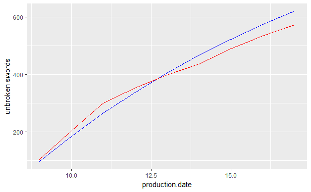

```r
production.date <- (9:17)
unbroken <- rep(swords.mean, 9)
unbroken <- unbroken*(1-risk.west)^(1:9)
unbroken <- cumsum(unbroken)
west.model <- data.frame(production.date, unbroken)
unbroken <- rep(swords.mean, 9)
unbroken <- c(unbroken[1:3]*(1-risk.harp.1)^(1:3),
              unbroken[4:9]*(1-risk.harp.2)^(4:6))
unbroken <- cumsum(unbroken)
harp.model <- data.frame(production.date, unbroken)
models <- data.frame(production.date, west.model$unbroken, harp.model$unbroken)
ggplot(models, aes(x = production.date), color=condition) +
  geom_line(aes(y=west.model.unbroken), color="blue") +
  geom_line(aes(y=harp.model.unbroken), color="red") +
  ylab("unbroken swords") +
  scale_color_manual(values = c(Westeros.Inc = "red", Harpy.Co = "blue"))
```

По графику нельзя однозначно оценить правильность выбора конкретного поставщика. Для численного сравнения поставщиков введем численную характеристику их пользы. Выразим это как время работы всех мечей в течение горизонта планирования.

Для этого достаточно найти матожидание исправности меча для каждого из поставщиков. Выберем для этого распределение Бернулли с модификациями. Первая модификация – изменение вероятности поломки меча из стали Harpy.Co спустя 3 месяца эксплуатации. Вторая – мы условимся, что в конце горизонта планирования все мечи ломаются, так как их полезность становится равной нулю.

```r
expect.west <- function(n) {
  prob.west <- rep(risk.west, n)
  prob.west <- c(prob.west*(1-risk.west)^(0:(n-1)), (1-risk.west)^(n))
  mean.west <- sum(prob.west*(1:(n+1)))
  return(mean.west)
}

expect.west.all = mean(sapply((1:9), expect.west))

expect.harp <- function(n) {
  prob.harp <- c(risk.harp.1, risk.harp.1*(1-risk.harp.1),
                 risk.harp.1*(1-risk.harp.1)^2)
  temp <- rep(risk.harp.2*(1-risk.harp.1)^3, 6)
  prob.harp <- c(prob.harp, temp*(1-risk.harp.2)^(0:5))
  prob.harp <- head(prob.harp, n)
  if(n == 1) {
    prob.harp <- c(prob.harp, 1-risk.harp.1)
  } else if(n == 2) {
    prob.harp <- c(prob.harp, (1-risk.harp.1)^2)
  } else {
    prob.harp <- c(prob.harp, (1-risk.harp.1)^3*(1-risk.harp.2)^(n-3))
  }
  mean.harp <- sum(prob.harp*(1:(n+1)))
  return(mean.harp)
}

expect.harp.all = mean(sapply((1:9), expect.harp))

print(expect.harp.all)
print(expect.west.all)
```

[output not shown]

Мы получили, что мечи из стали Harpy.Co долговечнее на ~0.3 месяца, а значит, именно эту компанию нужно выбрать в качестве эксклюзивного поставщика.